# Práctica de Aprendizaje Computacional

## 3.3 Análisis multivariable

Analizar todas las posibles agrupaciones de atributos sería una tarea inabarcable. Al contar con 16 de los mismos, existen un total de 2<sup>16</sup> = 65536 combinaciones de conjuntos. Es por ello que incluimos solo análisis de grupos de atributos que consideramos que pueden tener importancia.

Los objetivos del análisis multivariable es detectar patrones complejos no visibles en análisis univariantes. Nos puede servir posteriormente para reducir dimensiones o justificar otras decisiones de preprocesado.

### 3.3.1 Grid de variables numéricas

Utilizando un **pairwise correlation plot** con la función del paquete GGally vamos a visualizar las relaciones entre todos los pares de variables numéricas. Distinguimos entre créditos aprobados (azul) y denegados (rojo). No incluimos el código postal ya que no es un valor que mantenga un concepto de escala.

Dado que las variables Deuda, Anos_cotizados y Calificacion_crediticia presentan distribuciones muy sesgadas hacia valores bajos, aplicamos una transformación logarítmica. Así, se estabilizamos las varianzas y favorecemos el análisis de regresiones lineales.

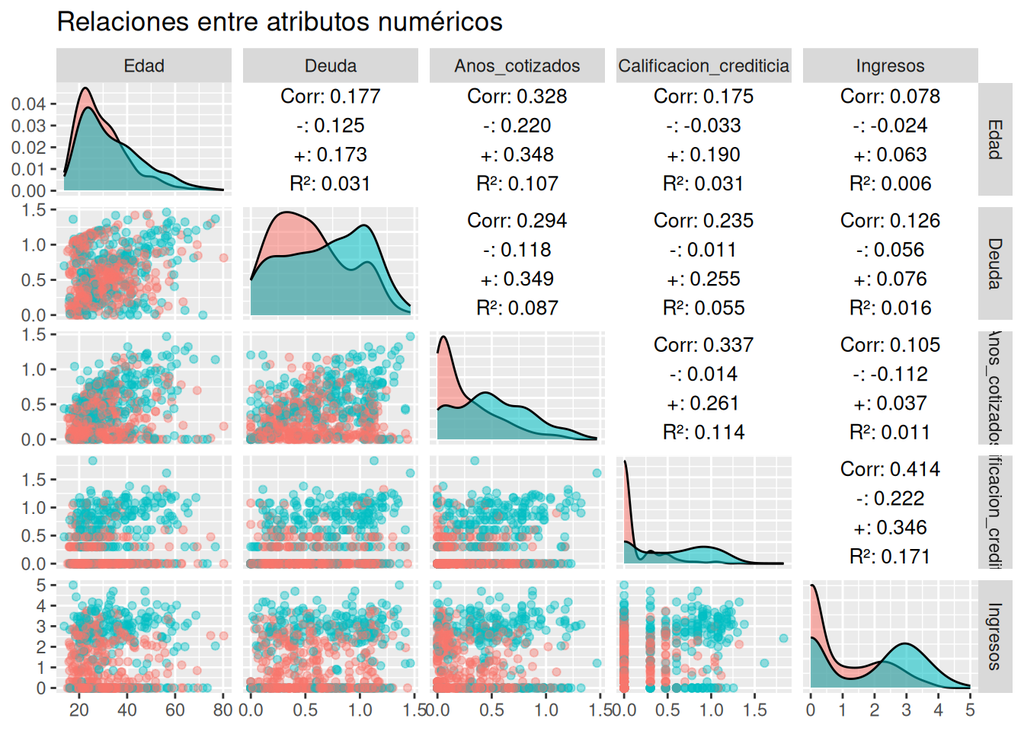

```r
# Función para mostrar R^2 en los paneles superiores
  cor_plus_r2_fun <- function(data, mapping, ...) {
    x <- eval_data_col(data, mapping$x)
    y <- eval_data_col(data, mapping$y)
    class_var <- data$Aprobado  # Asumimos que la clase es esta

    df <- data.frame(x = x, y = y, clase = class_var)
    df <- df[complete.cases(df), ]

    # Correlaciones
    r_total <- cor(df$x, df$y)
    r_plus  <- tryCatch(cor(df$x[df$clase == "+"], df$y[df$clase == "+"]), error = function(e) NA)
    r_minus <- tryCatch(cor(df$x[df$clase == "-"], df$y[df$clase == "-"]), error = function(e) NA)

    # R² global
    r2 <- tryCatch(summary(lm(y ~ x, data = df))$r.squared, error = function(e) NA)

    # Formato
    txt <- paste0(
      "Corr: ", sprintf("%.3f", r_total), "\n",
      "-: ", sprintf("%.3f", r_minus), "\n",
      "+: ", sprintf("%.3f", r_plus), "\n",
      "R²: ", sprintf("%.3f", r2)
    )

    ggplot(data = df, aes(x = x, y = y)) +
      annotate("text", x = median(df$x, na.rm = TRUE), y = median(df$y, na.rm = TRUE),
              label = txt, size = 3.5, hjust = 0.5) +
      theme_void()
  }

  # Subconjunto con las variables numéricas
  subset_credit <- credit[, c("Edad", "Deuda", "Anos_cotizados", "Calificacion_crediticia", "Ingresos", "Aprobado")]
  subset_credit$Deuda <- log10(subset_credit$Deuda + 1)
  subset_credit$Anos_cotizados <- log10(subset_credit$Anos_cotizados + 1)
  subset_credit$Ingresos <- log10(subset_credit$Ingresos + 1)
  subset_credit$Calificacion_crediticia <- log10(subset_credit$Calificacion_crediticia + 1)


  # Graficar con color por clase
  ggpairs(subset_credit,
          mapping = aes(color = Aprobado, alpha = 0.5),
          columns = 1:5,
          upper = list(continuous = cor_plus_r2_fun),
          lower = list(continuous = wrap("points", alpha = 0.4)),
          title = "Relaciones entre atributos numéricos")
```

Como puede observarse en la matriz de correlaciones, la diagonal corresponde a las distribuciones marginales que mostrábamos en el análisis monovariable. El triángulo inferior contiene los diagramas de dispersión para cada par de variables y clase (aprovado o denegado). Por último, el triángulo superior derecho contiene los coeficientes de correlación de Pearson, tanto de las distribuciones globales como las separadas por clase.

Las correlaciones son, en su mayoría, positivas y de pequeña magnitud. Tiene sentido, por ejemplo, que a mayor edad tenga una persona, más larga sea su vida laboral. Estas correlaciones son más intensas en la clase `+`. Esto suguiere que los casos aprobados siguen patrones más regulares. En el caso de la relación `Edad`-`Anos_cotizados`, podríamos interpretar que a la hora de la concesión de un crédito a una persona joven, se es mas laxo con una vida laboral más corta. No obstante, si nos fijamos en los gráficos de dispersión y en el R<sup>2</sup>, podemos concluir que los datos no son los idóneos para una regresión lineal.

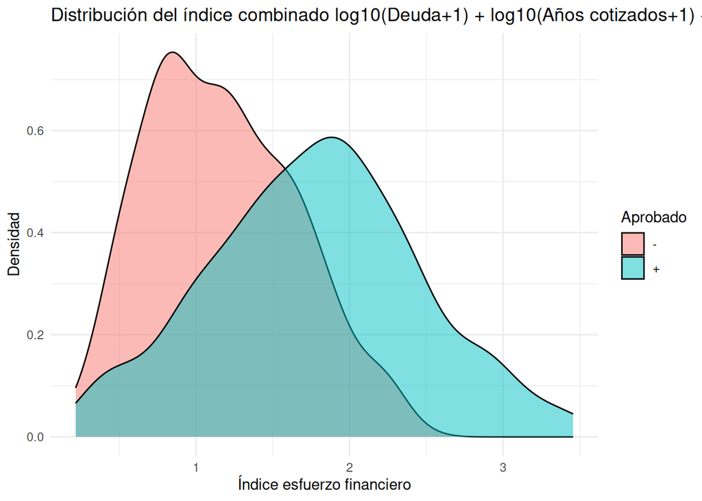

```r
subset_credit$Esfuerzo_financiero <- subset_credit$Deuda + subset_credit$Anos_cotizados  + abs(subset_credit$Ingresos-1)*0.375


ggplot(subset_credit, aes(x = Esfuerzo_financiero, fill = Aprobado)) +
  geom_density(alpha = 0.5) +
  theme_minimal() +
  labs(title = "Distribución del índice combinado log10(Deuda+1) + log10(Años cotizados+1) + |Igresos-1|*0.375" ,
       x = "Índice esfuerzo financiero", y = "Densidad")
```

### 3.3.2 Relaciones del índice crediticio

La calificación crediticia es, a priori, el mejor clasificador monovariable. No obstante, sigue habiendo unos pocos casos en los que una calificación alta no implica la concesión del crédito. En esta subsección vamos a intentar encontrar cuáles son las variables que determinan la concesión del crédito en los casos de un índice crediticio alto.

Para empezar, filtramos el dataset para contener únicamente información sobre los créditos en los que el solicitante tiene un índice crediticio superior a 3.

```r
  credit_alto <- subset(credit, Calificacion_crediticia > 3)
  summary(credit_alto)
```

```
##  Sexo        Edad           Deuda        Estado_civil Es_cliente
##  a:54   Min.   :16.08   Min.   : 0.000   l:  0        g :133
##  b:97   1st Qu.:24.00   1st Qu.: 1.750   u:133        gg:  0
##         Median :33.17   Median : 5.665   y: 18        p : 18
##         Mean   :35.43   Mean   : 6.739   t:  0
##         3rd Qu.:43.16   3rd Qu.:10.312
##         Max.   :68.67   Max.   :28.000
##
##  Nivel_educativo     Etnia    Anos_cotizados   Impago_previo Trabaja
##  c      :34      v      :80   Min.   : 0.000   f: 10         f:  0
##  q      :26      h      :40   1st Qu.: 1.000   t:141         t:151
##  cc     :14      bb     :15   Median : 2.375
##  w      :13      ff     : 9   Mean   : 4.010
##  x      :13      z      : 4   3rd Qu.: 5.250
##  i      : 9      dd     : 1   Max.   :28.500
##  (Other):42      (Other): 2
##  Calificacion_crediticia Licencia_de_conducir Ciudadano Codigo_postal
##  Min.   : 4.000          f:82                 g:149     Min.   :  0.0
##  1st Qu.: 6.000          t:69                 p:  0     1st Qu.:  0.0
##  Median : 8.000                               s:  2     Median :100.0
##  Mean   : 9.344                                         Mean   :141.4
##  3rd Qu.:11.000                                         3rd Qu.:220.0
##  Max.   :67.000                                         Max.   :583.0
##                                                         NA's   :2
##     Ingresos         Aprobado
##  Min.   :    0.0   Length:151
##  1st Qu.:    7.5   Class :character
##  Median :  540.0   Mode  :character
##  Mean   : 1919.4
##  3rd Qu.: 1802.5
##  Max.   :51100.0
##
```

Si repetimos la matriz de correlaciones para este dataset:

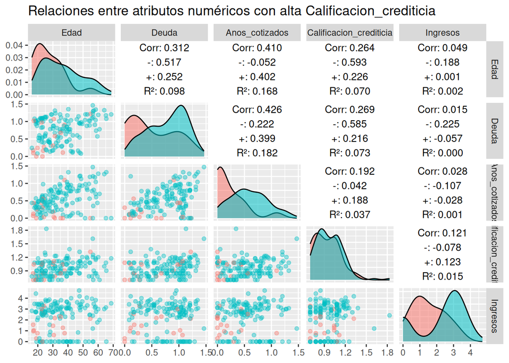

```r
# Función para mostrar R^2 en los paneles superiores
  cor_plus_r2_fun <- function(data, mapping, ...) {
    x <- eval_data_col(data, mapping$x)
    y <- eval_data_col(data, mapping$y)
    class_var <- data$Aprobado  # Asumimos que la clase es esta

    df <- data.frame(x = x, y = y, clase = class_var)
    df <- df[complete.cases(df), ]

    # Correlaciones
    r_total <- cor(df$x, df$y)
    r_plus  <- tryCatch(cor(df$x[df$clase == "+"], df$y[df$clase == "+"]), error = function(e) NA)
    r_minus <- tryCatch(cor(df$x[df$clase == "-"], df$y[df$clase == "-"]), error = function(e) NA)

    # R² global
    r2 <- tryCatch(summary(lm(y ~ x, data = df))$r.squared, error = function(e) NA)

    # Formato
    txt <- paste0(
      "Corr: ", sprintf("%.3f", r_total), "\n",
      "-: ", sprintf("%.3f", r_minus), "\n",
      "+: ", sprintf("%.3f", r_plus), "\n",
      "R²: ", sprintf("%.3f", r2)
    )

    ggplot(data = df, aes(x = x, y = y)) +
      annotate("text", x = median(df$x, na.rm = TRUE), y = median(df$y, na.rm = TRUE),
              label = txt, size = 3.5, hjust = 0.5) +
      theme_void()
  }

  # Subconjunto con las variables numéricas
  subset_credit <- credit_alto[, c("Edad", "Deuda", "Anos_cotizados", "Calificacion_crediticia", "Ingresos", "Aprobado")]
  subset_credit$Deuda <- log10(subset_credit$Deuda + 1)
  subset_credit$Anos_cotizados <- log10(subset_credit$Anos_cotizados + 1)
  subset_credit$Ingresos <- log10(subset_credit$Ingresos + 1)
  subset_credit$Calificacion_crediticia <- log10(subset_credit$Calificacion_crediticia + 1)


  # Graficar con color por clase
  ggpairs(subset_credit,
          mapping = aes(color = Aprobado, alpha = 0.5),
          columns = 1:5,
          upper = list(continuous = cor_plus_r2_fun),
          lower = list(continuous = wrap("points", alpha = 0.4)),
          title = "Relaciones entre atributos numéricos con alta Calificacion_crediticia")
```

los resultados obtenidos sugieren que los ingresos del solicitante son un factor clave en la concesión o no del crédito, resultando en una denegación aquellos perfiles con unos ingresos cercanos a 10 unidades. También destaca la diferencia entre una deuda alta y baja. De hecho, si utilizamos el `Esfuerzo_financiero` que hemos definido antes obtenemos el siguiente resultado:

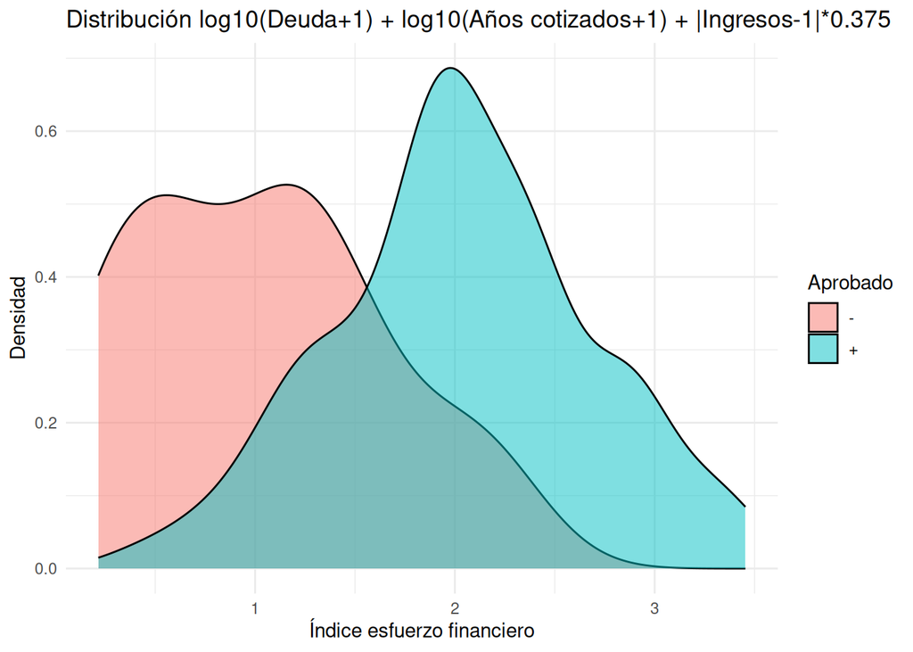

```r
subset_credit$Esfuerzo_financiero <- abs(subset_credit$Ingresos-1)*0.375 + subset_credit$Anos_cotizados + subset_credit$Deuda


ggplot(subset_credit, aes(x = Esfuerzo_financiero, fill = Aprobado)) +
  geom_density(alpha = 0.5) +
  theme_minimal() +
  labs(title = "Distribución log10(Deuda+1) + log10(Años cotizados+1) + |Ingresos-1|*0.375",
       x = "Índice esfuerzo financiero", y = "Densidad")
```

La separación es aún mejor que en el caso general. Podemos ver el rendimiento de este predictor para este subdataset:

```r
  subset_credit$Prediccion_simple <- ifelse(subset_credit$Esfuerzo_financiero > 1.6, "+", "-")
  table(Real = subset_credit$Aprobado, Predicho = subset_credit$Prediccion_simple)
```

```
##     Predicho
## Real   -   +
##    -  13   3
##    +  33 102
```

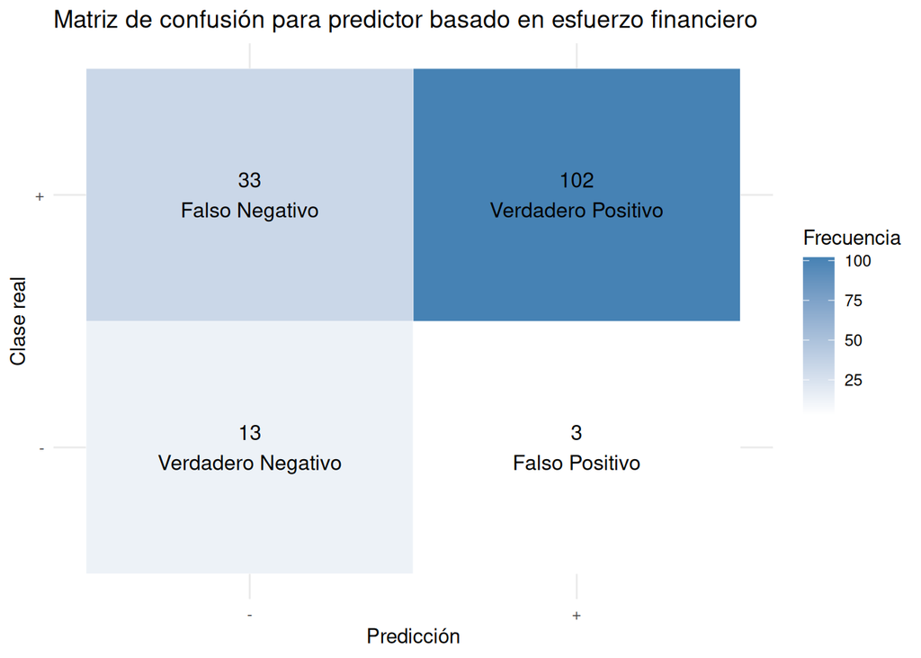

```r
  library(ggplot2)
  library(dplyr)

  # Crear tabla de confusión en formato largo
  conf_mat <- table(Real = subset_credit$Aprobado, Predicho = subset_credit$Prediccion_simple)
  conf_df <- as.data.frame(conf_mat)

  # Añadir etiquetas
  conf_df <- conf_df %>%
    mutate(Tipo = case_when(
      Real == "+" & Predicho == "+" ~ "Verdadero Positivo",
      Real == "-" & Predicho == "+" ~ "Falso Positivo",
      Real == "-" & Predicho == "-" ~ "Verdadero Negativo",
      Real == "+" & Predicho == "-" ~ "Falso Negativo"
    ))


  # Gráfico
  ggplot(conf_df, aes(x = Predicho, y = Real, fill = Freq)) +
    geom_tile(color = "white") +
    geom_text(aes(label = paste0(Freq, "\n", Tipo)), size = 4) +
    scale_fill_gradient(low = "white", high = "steelblue") +
    labs(title = "Matriz de confusión para predictor basado en esfuerzo financiero",
        x = "Predicción", y = "Clase real", fill = "Frecuencia") +
    theme_minimal()
```

# 4 Preprocesado de datos

```r
# Preprocesado 1 y preprocesado 2 para comparar más adelante
    # Cargar índices de train
    credit.trainIdx <- readRDS("credit.trainIdx")

    # Separación de conjuntos
    credit.Datos.Train <- credit[credit.trainIdx, ]
    credit.Datos.Test <- credit[-credit.trainIdx, ]
```

## 4.1 Tratamiento de los valores nulos

En primer lugar, veamos si hay valores nulos y cuántos hay en cada columna:

```r
# Una sola línea para contar nulos por columna
colSums(is.na(credit))
```

```
##                    Sexo                    Edad                   Deuda
##                      12                      12                       0
##            Estado_civil              Es_cliente         Nivel_educativo
##                       6                       6                       9
##                   Etnia          Anos_cotizados           Impago_previo
##                       9                       0                       0
##                 Trabaja Calificacion_crediticia    Licencia_de_conducir
##                       0                       0                       0
##               Ciudadano           Codigo_postal                Ingresos
##                       0                      13                       0
##                Aprobado
##                       0
```

En una gráfica podemos verlos mejor:

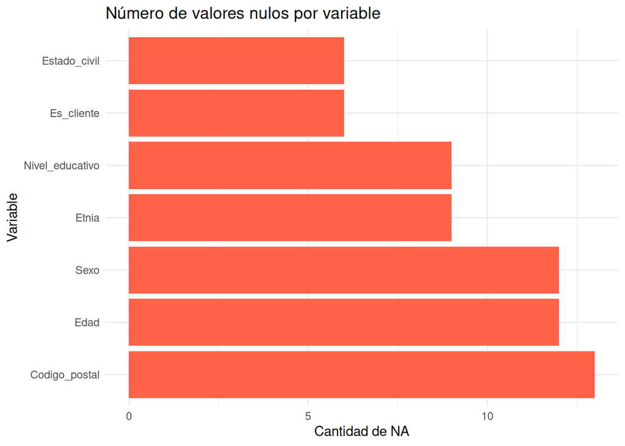

```r
# Visualización de los nulos con gráfico de barras
library(ggplot2)

nulos <- colSums(is.na(credit))
nulos_df <- data.frame(Variable = names(nulos), Nulos = nulos)
nulos_df <- nulos_df[nulos_df$Nulos > 0, ]  # Solo mostrar columnas con nulos

ggplot(nulos_df, aes(x = reorder(Variable, -Nulos), y = Nulos)) +
  geom_bar(stat = "identity", fill = "tomato") +
  labs(title = "Número de valores nulos por variable",
       x = "Variable", y = "Cantidad de NA") +
  theme_minimal() +
  coord_flip()
```

Vemos que solo 7 de los atributos tienen valores nulos y además la cantidad de estos es muy pequeña (cercano al 1% en todos los casos).

Es interesante saber cómo se distribuyen los valores nulos a lo largo de las muestras. Para ello vamos a ver la frecuencia del número de atributos faltantes. Ya trabajamos con los datos de Train, pues no debemos modificar los datos de Test a partir de ahora.

```r
# Número de valores NA por fila
na_por_fila <- rowSums(is.na(credit.Datos.Train ))

# Observaciones con al menos un NA
con_na <- na_por_fila[na_por_fila > 0]
length(con_na)  # ¿Cuántas observaciones tienen al menos un NA?
```

```
## [1] 37
```

```r
# Tabla resumen
table(con_na)
```

```
## con_na
##  1  2  3  5
## 27  2  2  6
```

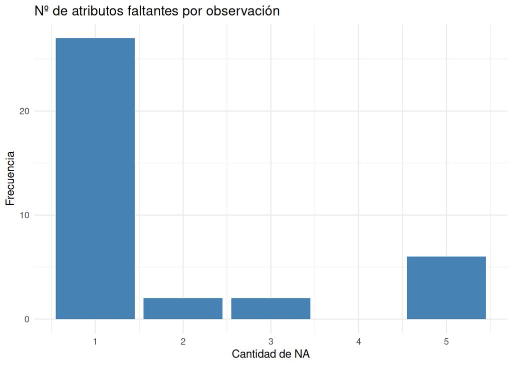

```r
# Histograma: cuántos atributos faltan por observación (entre las que tienen algún NA)
library(ggplot2)

ggplot(data.frame(Faltantes = con_na), aes(x = Faltantes)) +
  geom_bar(fill = "steelblue") +
  labs(title = "Nº de atributos faltantes por observación",
       x = "Cantidad de NA",
       y = "Frecuencia") +
  theme_minimal()
```

Vemos que a la mayoría de muestras con valores NA solo les falta un valor. Sin embargo, también es importante destacar que hay 6 muestras a las cuales les faltan 5 valores.

Como estrategia de limpieza, se han eliminado las observaciones del conjunto de entrenamiento que contenían más de 4 valores nulos. Esta decisión se justifica por el hecho de que esas observaciones presentan información muy incompleta, y su imputación generaría más ruido que beneficio. El resto de las observaciones, con pocos valores faltantes, se conservarán y se decidirá si se inputan o no posteriormente.

```r
# Eliminar observaciones con más de 4 atributos faltantes
credit.Datos.Train <- credit.Datos.Train[na_por_fila <= 4, ]

# Verificamos tamaño tras limpieza
nrow(credit.Datos.Train)
```

```
## [1] 547
```

Los valores nulos deben tratarse adecuadamente antes de entrenar modelos de aprendizaje automático. Las posibles estrategias incluyen:

- Eliminación de filas: útil si el número de nulos es pequeño y su eliminación no reduce significativamente el tamaño del dataset.
- Imputación por la media/mediana/moda: recomendable para variables numéricas si el porcentaje de nulos es moderado.
- Imputación por valor más frecuente: útil en variables categóricas con pocos niveles.
- Modelado de imputación: usar modelos predictivos (por ejemplo mice, missForest) para estimar los valores faltantes, aunque es más costoso computacionalmente.

En nuestro caso, es probable que la mejor opción sea simplemente eliminar las filas con datos faltantes, pues como hemos visto en la gráfica anterior, hay muy pocos valores nulos en comparación con el número total de muestras que disponemos.